# Table of Contents

## Data Description:

##### The file Bank.xls contains data on 5000 customers. The data include customer demographic information (age, income, etc.), the customer's relationship with the bank (mortgage, securities account, etc.), and the customer response to the last personal loan campaign (Personal Loan). Among these 5000 customers, only 480 (= 9.6%) accepted the personal loan that was offered to them in the earlier campaign.

## Domain:

## Context:

##### This case is about a bank (Thera Bank) whose management wants to explore ways of converting its liability customers to personal loan customers (while retaining them as depositors). A campaign that the bank ran last year for liability customers showed a healthy conversion rate of over 9% success. This has encouraged the retail marketing department to devise campaigns with better target marketing to increase the success ratio with minimal budget.

## Attribute Information:

- ID : Customer ID
- Age : Customer's age in completed years
- Experience : years of professional experience
- Income : Annual income of the customer
- ZIP Code : Home Address ZIP code.
- Family : Family size of the customer
- CCAvg : Avg. spending on credit cards per month
- Education : Education Level. 1: Undergrad; 2: Graduate, 3: Advanced/Professional
- Mortgage : Value of house mortgage if any.
- Personal Loan : Did this customer accept the personal loan offered in the last campaign?
- Securities Account : Does the customer have a securities account with the bank?
- CD Account : Does the customer have a certificate of deposit (CD) account with the bank?
- Online : Does the customer use internet banking facilities?
- Credit card : Does the customer use a credit card issued by UniversalBank?

## Learning Outcomes:

- Exploratory Data Analysis
- Preparing the data to train a model
- Training and making predictions using a classification model
- Model evaluation

## Objective:

- The classification goal is to predict the likelihood of a liability customer buying personal loans.

## Steps and tasks:

1. Read the column description and ensure you understand each attribute well
2. Study the data distribution in each attribute, share your findings
3. Get the target column distribution. Your comments
4. Split the data into training and test set in the ratio of 70:30 respectively
5. Use different classification models (Logistic, K-NN and Naïve Bayes) to predict the likelihood of a liability customer buying personal loans
6. Print the confusion matrix for all the above models
7. Give your reasoning on which is the best model in this case and why it performs better?

# Importing Packages and Reading file

```python
import numpy as np #import numpy
import pandas as pd #import pandas
import seaborn as sns # import seaborn
import matplotlib.pyplot as plt #import pyplot
%matplotlib inline
from scipy.stats import pearsonr #for pearson's correlation

from sklearn.model_selection import train_test_split #for splitting the data in train and test
from sklearn.preprocessing import StandardScaler,MinMaxScaler,RobustScaler #for various scaling methods
from sklearn.linear_model import LogisticRegression #for LogisticRegression
from sklearn.naive_bayes import GaussianNB #for NaiveBayes
from sklearn.neighbors import KNeighborsClassifier #for KNN
from sklearn.svm import SVC #for Support vector classifier

from sklearn.metrics import accuracy_score,confusion_matrix,recall_score #for accuracy matrices
from sklearn.metrics import precision_score,classification_report,roc_auc_score,precision_score #for accuracy matrices
```

```python
DataFrame = pd.read_csv('Bank_Personal_Loan_Modelling.csv') #reading the CSV file
DataFrame.head() #to check head of the dataframe
```

|  | ID | Age | Experience | Income | ZIP Code | Family | CCAvg | Education | Mortgage | Personal Loan | Securities Account | CD Account | Online | CreditCard |
| --- | --- | --- | --- | --- | --- | --- | --- | --- | --- | --- | --- | --- | --- | --- |
| 0 | 1 | 25 | 1 | 49 | 91107 | 4 | 1.6 | 1 | 0 | 0 | 1 | 0 | 0 | 0 |
| 1 | 2 | 45 | 19 | 34 | 90089 | 3 | 1.5 | 1 | 0 | 0 | 1 | 0 | 0 | 0 |
| 2 | 3 | 39 | 15 | 11 | 94720 | 1 | 1.0 | 1 | 0 | 0 | 0 | 0 | 0 | 0 |
| 3 | 4 | 35 | 9 | 100 | 94112 | 1 | 2.7 | 2 | 0 | 0 | 0 | 0 | 0 | 0 |
| 4 | 5 | 35 | 8 | 45 | 91330 | 4 | 1.0 | 2 | 0 | 0 | 0 | 0 | 0 | 1 |

```python
DataFrame.tail() #to check tail of the dataframe
```

|  | ID | Age | Experience | Income | ZIP Code | Family | CCAvg | Education | Mortgage | Personal Loan | Securities Account | CD Account | Online | CreditCard |
| --- | --- | --- | --- | --- | --- | --- | --- | --- | --- | --- | --- | --- | --- | --- |
| 4995 | 4996 | 29 | 3 | 40 | 92697 | 1 | 1.9 | 3 | 0 | 0 | 0 | 0 | 1 | 0 |
| 4996 | 4997 | 30 | 4 | 15 | 92037 | 4 | 0.4 | 1 | 85 | 0 | 0 | 0 | 1 | 0 |
| 4997 | 4998 | 63 | 39 | 24 | 93023 | 2 | 0.3 | 3 | 0 | 0 | 0 | 0 | 0 | 0 |
| 4998 | 4999 | 65 | 40 | 49 | 90034 | 3 | 0.5 | 2 | 0 | 0 | 0 | 0 | 1 | 0 |
| 4999 | 5000 | 28 | 4 | 83 | 92612 | 3 | 0.8 | 1 | 0 | 0 | 0 | 0 | 1 | 1 |

# Exploratory Data Analysis

## Shape of the data

```python
print('\033[1m''Number of rows in dataframe',DataFrame.shape[0]) #for number of rows
print('\033[1m''Number of features in dataframe',DataFrame.shape[1]) #for number of features
```

```
Number of rows in dataframe 5000
Number of features in dataframe 14
```

- The dataset has 5000 rows and 14 columns(features)

## Data type of each attribute

```python
DataFrame.dtypes.to_frame('Datatypes of attributes').T #for datatypes of attributes
```

|  | ID | Age | Experience | Income | ZIP Code | Family | CCAvg | Education | Mortgage | Personal Loan | Securities Account | CD Account | Online | CreditCard |
| --- | --- | --- | --- | --- | --- | --- | --- | --- | --- | --- | --- | --- | --- | --- |
| Datatypes of attributes | int64 | int64 | int64 | int64 | int64 | int64 | float64 | int64 | int64 | int64 | int64 | int64 | int64 | int64 |

- Majority of datatypes are integer and one dimension is float

## Checking the presence of missing values

```python
DataFrame.isnull().sum().to_frame('Presence of missing values').T #for checking presence of missing values
```

|  | ID | Age | Experience | Income | ZIP Code | Family | CCAvg | Education | Mortgage | Personal Loan | Securities Account | CD Account | Online | CreditCard |
| --- | --- | --- | --- | --- | --- | --- | --- | --- | --- | --- | --- | --- | --- | --- |
| Presence of missing values | 0 | 0 | 0 | 0 | 0 | 0 | 0 | 0 | 0 | 0 | 0 | 0 | 0 | 0 |

- The dataset has no missing values

## 5 point summary of numerical attributes (Univariate Analysis)

```python
DataFrame.describe().T #for 5 point summary
```

|  | count | mean | std | min | 25% | 50% | 75% | max |
| --- | --- | --- | --- | --- | --- | --- | --- | --- |
| ID | 5000.0 | 2500.500000 | 1443.520003 | 1.0 | 1250.75 | 2500.5 | 3750.25 | 5000.0 |
| Age | 5000.0 | 45.338400 | 11.463166 | 23.0 | 35.00 | 45.0 | 55.00 | 67.0 |
| Experience | 5000.0 | 20.104600 | 11.467954 | -3.0 | 10.00 | 20.0 | 30.00 | 43.0 |
| Income | 5000.0 | 73.774200 | 46.033729 | 8.0 | 39.00 | 64.0 | 98.00 | 224.0 |
| ZIP Code | 5000.0 | 93152.503000 | 2121.852197 | 9307.0 | 91911.00 | 93437.0 | 94608.00 | 96651.0 |
| Family | 5000.0 | 2.396400 | 1.147663 | 1.0 | 1.00 | 2.0 | 3.00 | 4.0 |
| CCAvg | 5000.0 | 1.937938 | 1.747659 | 0.0 | 0.70 | 1.5 | 2.50 | 10.0 |
| Education | 5000.0 | 1.881000 | 0.839869 | 1.0 | 1.00 | 2.0 | 3.00 | 3.0 |
| Mortgage | 5000.0 | 56.498800 | 101.713802 | 0.0 | 0.00 | 0.0 | 101.00 | 635.0 |
| Personal Loan | 5000.0 | 0.096000 | 0.294621 | 0.0 | 0.00 | 0.0 | 0.00 | 1.0 |
| Securities Account | 5000.0 | 0.104400 | 0.305809 | 0.0 | 0.00 | 0.0 | 0.00 | 1.0 |
| CD Account | 5000.0 | 0.060400 | 0.238250 | 0.0 | 0.00 | 0.0 | 0.00 | 1.0 |
| Online | 5000.0 | 0.596800 | 0.490589 | 0.0 | 0.00 | 1.0 | 1.00 | 1.0 |
| CreditCard | 5000.0 | 0.294000 | 0.455637 | 0.0 | 0.00 | 0.0 | 1.00 | 1.0 |

### 5 point summary understanding:

- Minumum value for Experience column is -3,experience cannot be negative years
- Outliers are present in 'income', 'CCAvg' and 'Mortgage' columns.
- Distribution of 'income', 'CCAvg' and 'Mortgage' columns is right skewed.
- Maximum and Minimum age are 67 and 23 respectively.
- Some Experience is '-'ve and maximum experience is 43 years
- More than 50% customers use online facilities
- Less than 50% customers use credit card

## Distribution of columns.

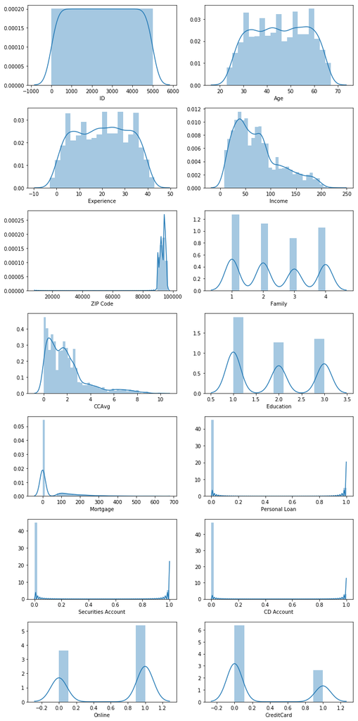

```python
fig, axe = plt.subplots(nrows=7, ncols=2, figsize=(10, 20))
axe = axe.flatten() #to flatten subplot index positions
sns.distplot(DataFrame['ID'],ax=axe[0]) #Distance plot of 'ID'
sns.distplot(DataFrame['Age'],ax=axe[1]) #Distance plot of 'Age'
sns.distplot(DataFrame['Experience'],ax=axe[2]) #Distance plot of 'Experience'
sns.distplot(DataFrame['Income'],ax=axe[3]) #Distance plot of 'Income'
sns.distplot(DataFrame['ZIP Code'],ax=axe[4]) #Distance plot of 'ZIP Code'
sns.distplot(DataFrame['Family'],ax=axe[5]) #Distance plot of 'Family'
sns.distplot(DataFrame['CCAvg'],ax=axe[6]) #Distance plot of 'CCAvg'
sns.distplot(DataFrame['Education'],ax=axe[7]) #Distance plot of 'Education'
sns.distplot(DataFrame['Mortgage'],ax=axe[8]) #Distance plot of 'Mortgage'
sns.distplot(DataFrame['Personal Loan'],ax=axe[9]) #Distance plot of 'Personal Loan'
sns.distplot(DataFrame['Securities Account'],ax=axe[10]) #Distance plot of 'Securities Account'
sns.distplot(DataFrame['CD Account'],ax=axe[11]) #Distance plot of 'CD Account '
sns.distplot(DataFrame['Online'],ax=axe[12]) #Distance plot of 'Online'
sns.distplot(DataFrame['CreditCard'],ax=axe[13]) #Distance plot of 'CreditCard'
fig.tight_layout() #for arranging the plots
fig.show() #display plots
```

### Understanding from distributions

- As per initial findings in Univariate Analysis(5 point summary) Distribution of 'income', 'CCAvg' and 'Mortgage' columns is right skewed.
- There are Two classes in 'Online', 'CreditCard', 'Securities Acount', 'CD Account' and 'Personal Loan' columns
- There are 4 classes in 'Family' and 3 classes in 'Education' column
- Distribution of 'ZIP code' is left skewed
- The Data in 'ID' column is in the range of 1 to 5000 and is in increasing order
- Some correlation can be observed in 'Age' and 'Experience' columns' distributions
- For more than 50% customer value of Mortgage is 0

## Measure of skewness of columns

```python
DataFrame.skew().to_frame('Skewness measure').T #for measure of skewness
```

|  | ID | Age | Experience | Income | ZIP Code | Family | CCAvg | Education | Mortgage | Personal Loan | Securities Account | CD Account | Online | CreditCard |
| --- | --- | --- | --- | --- | --- | --- | --- | --- | --- | --- | --- | --- | --- | --- |
| Skewness measure | 0.0 | -0.029341 | -0.026325 | 0.841339 | -12.500221 | 0.155221 | 1.598443 | 0.227093 | 2.104002 | 2.743607 | 2.588268 | 3.691714 | -0.394785 | 0.904589 |

## Checking the presence of outliers

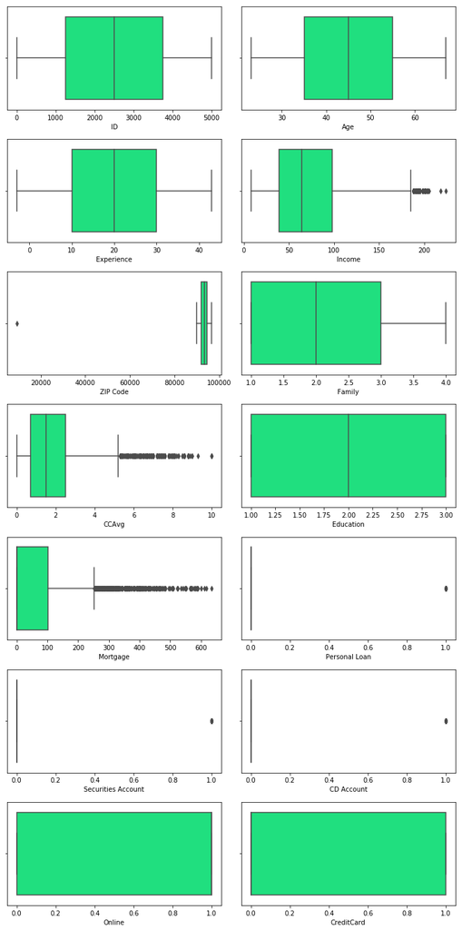

```python
fig, axe = plt.subplots(nrows=7, ncols=2, figsize=(10, 20))
axe = axe.flatten()#to flatten subplot index positions
sns.boxplot(x='ID',data=DataFrame,color='springgreen',ax=axe[0]) #Box plot of 'ID' for finding outliers
sns.boxplot(x='Age',data=DataFrame,color='springgreen',ax=axe[1]) #Box plot of 'Age'
sns.boxplot(x='Experience',data=DataFrame,color='springgreen',ax=axe[2]) #Box plot of 'Experience'
sns.boxplot(x='Income',data=DataFrame,color='springgreen',ax=axe[3])  #Box plot of 'Income'
sns.boxplot(x='ZIP Code',data=DataFrame,color='springgreen',ax=axe[4]) #Box plot of 'ZIP code'
sns.boxplot(x='Family',data=DataFrame,color='springgreen',ax=axe[5]) #Box plot of 'Family'
sns.boxplot(x='CCAvg',data=DataFrame,color='springgreen',ax=axe[6]) #Box plot of 'CCAvg'
sns.boxplot(x='Education',data=DataFrame,color='springgreen',ax=axe[7]) #Box plot of 'Education'
sns.boxplot(x='Mortgage',data=DataFrame,color='springgreen',ax=axe[8]) #Box plot of 'Mortgage'
sns.boxplot(x='Personal Loan',data=DataFrame,color='springgreen',ax=axe[9]) #Box plot of 'Personal Loan'
sns.boxplot(x='Securities Account',data=DataFrame,color='springgreen',ax=axe[10]) #Box plot of 'Securities Account'
sns.boxplot(x='CD Account',data=DataFrame,color='springgreen',ax=axe[11]) #Box plot of 'CD Account'
sns.boxplot(x='Online',data=DataFrame,color='springgreen',ax=axe[12]) #Box plot of 'Online'
sns.boxplot(x='CreditCard',data=DataFrame,color='springgreen',ax=axe[13]) #Box plot of 'CreditCard'
fig.tight_layout() #for arranging the plots
fig.show() #display plots
```

### Understanding from boxplots

- Prove the existance of outliers in 'income', 'CCAvg', 'Mortgage' columns as per observations from 5 point summary.
- Values less than 0 are present in 'Experience' column
- Distribution of 'income', 'CCAvg' and 'Mortgage' columns is right skewed.
- Some correlation can be observed in 'Age' and 'Experience' columns

## Distribution of Personal Loan column using Crosstable

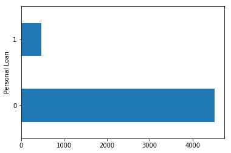

```python
cross_val=pd.crosstab(index=DataFrame['Personal Loan'],columns='count') #cross table of values in 'Personal Loan' column
cross_val.plot(kind='barh',legend=False) #plot of cross table
```

```python
DataFrame['Personal Loan'].value_counts() #Count of unique values in 'Personal Loan' column
```

```
0    4520
1     480
Name: Personal Loan, dtype: int64
```

- As per given data, among 5000 customers, only 480 (9.6%) accepted the personal loan that was offered to them in the earlier campaign.
- The data is not balanced, the ratio is 90:10 approximately. The performace of models cannot be guessed at this stage.
- Personal Loan column is our target column because the goal is to predict the probability of people who will opt for personal loan

# Data Preprocessing:

## Converting datatype of 'Personal Loan' to categorical

```python
DataFrame.dtypes.to_frame('Datatypes of attributes').T #for datatypes of attributes
```

|  | ID | Age | Experience | Income | ZIP Code | Family | CCAvg | Education | Mortgage | Personal Loan | Securities Account | CD Account | Online | CreditCard |
| --- | --- | --- | --- | --- | --- | --- | --- | --- | --- | --- | --- | --- | --- | --- |
| Datatypes of attributes | int64 | int64 | int64 | int64 | int64 | int64 | float64 | int64 | int64 | int64 | int64 | int64 | int64 | int64 |

```python
DataFrame['Personal Loan'] = pd.Categorical(DataFrame['Personal Loan']) #Conversion of target column datatype
```

```python
DataFrame.dtypes.to_frame('Datatypes of attributes').T #for datatypes of attributes
```

|  | ID | Age | Experience | Income | ZIP Code | Family | CCAvg | Education | Mortgage | Personal Loan | Securities Account | CD Account | Online | CreditCard |
| --- | --- | --- | --- | --- | --- | --- | --- | --- | --- | --- | --- | --- | --- | --- |
| Datatypes of attributes | int64 | int64 | int64 | int64 | int64 | int64 | float64 | int64 | int64 | category | int64 | int64 | int64 | int64 |

## Correlation between age and experience

###### As we have seen earlier some records have experience in negative. For fixing that lets check the correlation

```python
covariance = pearsonr(DataFrame['Age'],DataFrame['Experience']) #Pearsons covariance for checking
                                                                #correlation between Age and Experience
covariance
```

```
(0.9942148569683319, 0.0)
```

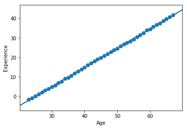

```python
sns.regplot(x='Age',y='Experience',data=DataFrame,x_estimator=np.mean) #Regression plot of 'Age' and 'Experience' columns
```

- From above pearsons corelation and Regression plot it can be observed that Age and Experience are highly corelated. The values were correct but with negative value.

### Replacing negative values:

```python
DF_copy = DataFrame.copy() #copy of original dataframe for processing
print('\033[1m''Number of records with -ve experience:',DF_copy[DF_copy['Experience']<0].shape[0])
```

```
Number of records with -ve experience: 52
```

```python
DF_copy['Experience'] = DF_copy['Experience'].apply(abs) #replacing negative value with absolute values
print('\033[1m''Number of records with -ve experience after correction:',DF_copy[DF_copy['Experience']<0].shape[0])
```

```
Number of records with -ve experience after correction: 0
```

## Removing columns:

- Id and Zip Code columns will not countribute in the process of model building as they are not related to Customers accepting the personal loan. Also, keeping them in further steps will increase processing load as well as reduce the performance of model in Production Stage.

```python
DF_copy = DF_copy.drop(['ID','ZIP Code'],axis=1) #Dropping ID and ZIP code columns
DF_copy.head() #Head of updated dataframe
```

|  | Age | Experience | Income | Family | CCAvg | Education | Mortgage | Personal Loan | Securities Account | CD Account | Online | CreditCard |
| --- | --- | --- | --- | --- | --- | --- | --- | --- | --- | --- | --- | --- |
| 0 | 25 | 1 | 49 | 4 | 1.6 | 1 | 0 | 0 | 1 | 0 | 0 | 0 |
| 1 | 45 | 19 | 34 | 3 | 1.5 | 1 | 0 | 0 | 1 | 0 | 0 | 0 |
| 2 | 39 | 15 | 11 | 1 | 1.0 | 1 | 0 | 0 | 0 | 0 | 0 | 0 |
| 3 | 35 | 9 | 100 | 1 | 2.7 | 2 | 0 | 0 | 0 | 0 | 0 | 0 |
| 4 | 35 | 8 | 45 | 4 | 1.0 | 2 | 0 | 0 | 0 | 0 | 0 | 1 |

## One hot Encoding of Education Column:

```python
DF_copy['Education'] = DF_copy['Education'].replace({1:'Undergrad',2:'Graduate',3:'Advanced/Professional'}) #replacing
                                                                                                            #values to original
DF_copy.head() #head of dataframe
```

|  | Age | Experience | Income | Family | CCAvg | Education | Mortgage | Personal Loan | Securities Account | CD Account | Online | CreditCard |
| --- | --- | --- | --- | --- | --- | --- | --- | --- | --- | --- | --- | --- |
| 0 | 25 | 1 | 49 | 4 | 1.6 | Undergrad | 0 | 0 | 1 | 0 | 0 | 0 |
| 1 | 45 | 19 | 34 | 3 | 1.5 | Undergrad | 0 | 0 | 1 | 0 | 0 | 0 |
| 2 | 39 | 15 | 11 | 1 | 1.0 | Undergrad | 0 | 0 | 0 | 0 | 0 | 0 |
| 3 | 35 | 9 | 100 | 1 | 2.7 | Graduate | 0 | 0 | 0 | 0 | 0 | 0 |
| 4 | 35 | 8 | 45 | 4 | 1.0 | Graduate | 0 | 0 | 0 | 0 | 0 | 1 |

```python
DF_copy=pd.get_dummies(DF_copy,columns=['Education']) #One hot encoding using pandas
DF_copy.head() #head of dataframe
```

|  | Age | Experience | Income | Family | CCAvg | Mortgage | Personal Loan | Securities Account | CD Account | Online | CreditCard | Education_Advanced/Professional | Education_Graduate | Education_Undergrad |
| --- | --- | --- | --- | --- | --- | --- | --- | --- | --- | --- | --- | --- | --- | --- |
| 0 | 25 | 1 | 49 | 4 | 1.6 | 0 | 0 | 1 | 0 | 0 | 0 | 0 | 0 | 1 |
| 1 | 45 | 19 | 34 | 3 | 1.5 | 0 | 0 | 1 | 0 | 0 | 0 | 0 | 0 | 1 |
| 2 | 39 | 15 | 11 | 1 | 1.0 | 0 | 0 | 0 | 0 | 0 | 0 | 0 | 0 | 1 |
| 3 | 35 | 9 | 100 | 1 | 2.7 | 0 | 0 | 0 | 0 | 0 | 0 | 0 | 1 | 0 |
| 4 | 35 | 8 | 45 | 4 | 1.0 | 0 | 0 | 0 | 0 | 0 | 1 | 0 | 1 | 0 |

# Corr plot of features

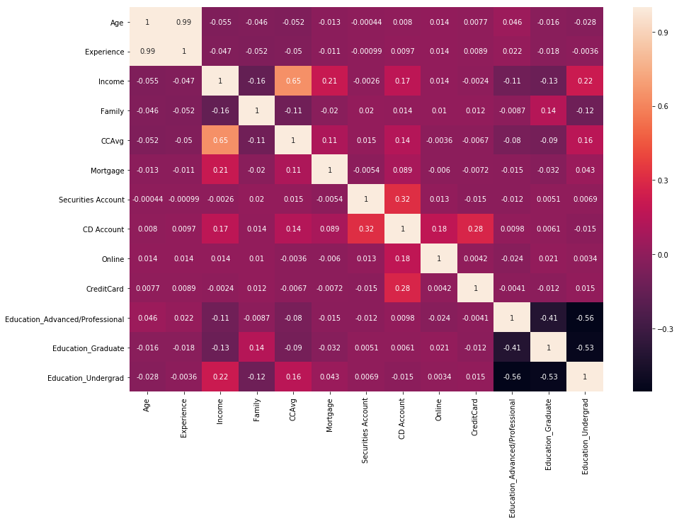

```python
plt.figure(figsize=(15,10)) #for adjusting figuresize
sns.heatmap(DF_copy.corr(),annot=True) #for correlation plot
```

# Pairplot of features

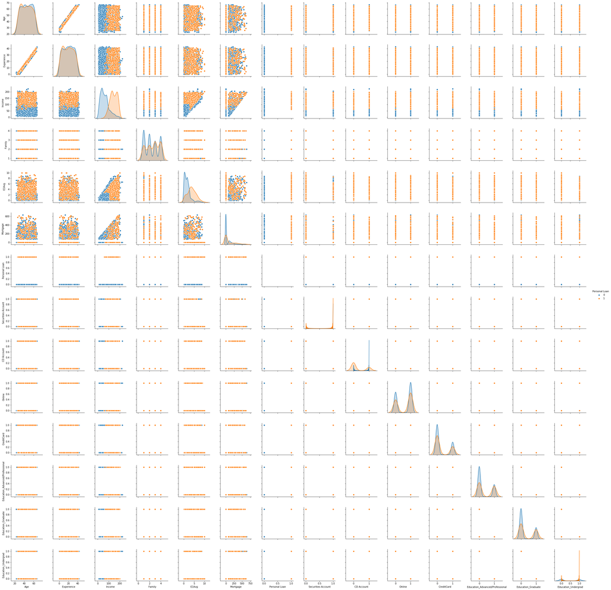

```python
plt.figure(figsize=(20,20)) #size in width and height
sns.pairplot(DF_copy,hue='Personal Loan') # pairplot of all dimensions which will be used for model building
plt.show() #display plots
```

# Train Test Split (70:30)

```python
X = DF_copy.drop('Personal Loan',axis=1) #independent dimensions
y = DF_copy['Personal Loan'] #selecting personal loan as it is target column

X_train,X_test,y_train,y_test = train_test_split(X,y,test_size=0.30,random_state=1) #train test split in 70:30 ratio
```

# Scaling of columns

```python
scaler = MinMaxScaler() #using standard scaler method
X_train_scaled = scaler.fit_transform(X_train) #Scaling of Train dataset
X_test_scaled = scaler.fit_transform(X_test) #Scaling of Test dataset
```

- MinMaxScaler reduced the model accuracy of Logistic Regression, KNN and Naive bayes, but incresed accuracy of SVC (Results compared with results of StandardScaler). Also, MinMax scaler is used when upper and lower boundries are fixed which is a subject to domain knowledge.
- As there are outliers in 3 columns so, I tried using RobustScaler, which reduced the model accuracy of Logistic Regression, KNN and Naive bayes, but incresed accuracy of SVC (Results compared with results of StandardScaler)

###### Different scaler methods cause difference in optimal K value in K-Nearest Neighbors algorithm.

# Models:

## Logistic Regression:

```python
logic_r = LogisticRegression(solver='liblinear') #Instantiate the LogisticRegression object
logic_r.fit(X_train_scaled,y_train) #Call the fit method of logistic regression to train the model or to learn the parameters of model
y_pred=logic_r.predict(X_test_scaled) #Predict
```

```python
print('\033[1m''->'*63)
print('\033[1m''Confusion Matrix\n',confusion_matrix(y_test,y_pred)) #for confusion matrix
print('-'*40)
LR_accuracy = accuracy_score(y_test,y_pred)
print('Accuracy of Logistic Regression :{:.2f}'.format(LR_accuracy)) #for accuracy score
print('-'*40)
print('\n Classification Report\n',classification_report(y_test,y_pred)) #for classification report
print('->'*63)
```

```
->->->->->->->->->->->->->->->->->->->->->->->->->->->->->->->->->->->->->->->->->->->->->->->->->->->->->->->->->->->->->->->
Confusion Matrix
 [[1334   17]
 [  48  101]]
----------------------------------------
Accuracy of Logistic Regression :0.96
----------------------------------------

 Classification Report
               precision    recall  f1-score   support

           0       0.97      0.99      0.98      1351
           1       0.86      0.68      0.76       149

   micro avg       0.96      0.96      0.96      1500
   macro avg       0.91      0.83      0.87      1500
weighted avg       0.95      0.96      0.95      1500

->->->->->->->->->->->->->->->->->->->->->->->->->->->->->->->->->->->->->->->->->->->->->->->->->->->->->->->->->->->->->->->
```

## Naive Bayes

```python
NB = GaussianNB()   #Instantiate the Gaussian Naive bayes
NB.fit(X_train_scaled,y_train) #Call the fit method of NB to train the model or to learn the parameters of model

y_predi = NB.predict(X_test_scaled) #Predict
```

```python
print('\033[1m''->'*63)
print('\033[1m''Confusion Matrix\n',confusion_matrix(y_test,y_predi)) #for confusion matrix
print('-'*30)
NB_accuracy = accuracy_score(y_test,y_predi)
print('Accuracy of Naive Bayes :{:.2f}'.format(NB_accuracy)) #for accuracy score
print('-'*30)
print('\n Classification Report\n',classification_report(y_test,y_predi)) #for classification report
print('->'*63)
```

```
->->->->->->->->->->->->->->->->->->->->->->->->->->->->->->->->->->->->->->->->->->->->->->->->->->->->->->->->->->->->->->->
Confusion Matrix
 [[1232  119]
 [  56   93]]
------------------------------
Accuracy of Naive Bayes :0.88
------------------------------

 Classification Report
               precision    recall  f1-score   support

           0       0.96      0.91      0.93      1351
           1       0.44      0.62      0.52       149

   micro avg       0.88      0.88      0.88      1500
   macro avg       0.70      0.77      0.72      1500
weighted avg       0.91      0.88      0.89      1500

->->->->->->->->->->->->->->->->->->->->->->->->->->->->->->->->->->->->->->->->->->->->->->->->->->->->->->->->->->->->->->->
```

## K-Nearest Neighbor

```python
# k=3
knn = KNeighborsClassifier(n_neighbors = 3)  #Instantiate KNN with k=3
knn.fit(X_train_scaled,y_train) #Call the fit method of KNN to train the model or to learn the parameters of model
y_predict = knn.predict(X_test_scaled) #Predict

print('\033[1m''->'*63)
print('\033[1m''Confusion Matrix\n',confusion_matrix(y_test,y_predi)) #for confusion matrix
print('-'*30)
KNN_accuracy = accuracy_score(y_test,y_predict)
print('Accuracy of KNN :{:.2f}'.format(KNN_accuracy)) #for accuracy score
print('-'*30)
print('\n Classification Report\n',classification_report(y_test,y_predi)) #for classification report
print('->'*63)
```

```
->->->->->->->->->->->->->->->->->->->->->->->->->->->->->->->->->->->->->->->->->->->->->->->->->->->->->->->->->->->->->->->
Confusion Matrix
 [[1232  119]
 [  56   93]]
------------------------------
Accuracy of KNN :0.96
------------------------------

 Classification Report
               precision    recall  f1-score   support

           0       0.96      0.91      0.93      1351
           1       0.44      0.62      0.52       149

   micro avg       0.88      0.88      0.88      1500
   macro avg       0.70      0.77      0.72      1500
weighted avg       0.91      0.88      0.89      1500

->->->->->->->->->->->->->->->->->->->->->->->->->->->->->->->->->->->->->->->->->->->->->->->->->->->->->->->->->->->->->->->
```

```
optimal k is 3
```

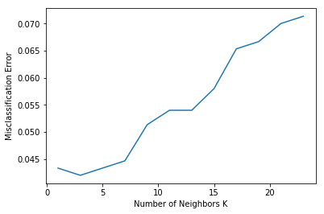

```python
oddList = list(np.arange(1,25)) #Range from 1 to 24
neighbors = list(filter(lambda x: x % 2 != 0, oddList)) #Selecting only odd numbers from Range 1 to 24

accuracy_list = [] #Empty list to store accuracy scores of KNN models based on various K values

for i in neighbors:
    knn = KNeighborsClassifier(n_neighbors = i) #Instantiate KNN with k=i
    knn.fit(X_train_scaled,y_train)  #Call the fit method of KNN to train the model or to learn the parameters of model
    y_pred = knn.predict(X_test_scaled) #Predict
    accuracy_s = accuracy_score(y_test,y_pred) #for accuracy score
    accuracy_list.append(accuracy_s)  #for appedning accuracy score to accuracy score list

MSE=[1 - j for j in accuracy_list] #calculation of Mean Squared Error

optimal = neighbors[MSE.index(min(MSE))] #Optimal K value selected by minimum MSE
print('optimal k is',optimal) #Print optimal K value selected by minimum MSE

plt.plot(neighbors,MSE) #MSE plot
plt.xlabel('Number of Neighbors K') #XLabel
plt.ylabel('Misclassification Error') #YLabel
plt.show() #display plot
```

## SVC

```python
svc = SVC()  #Instantiate SVC
svc.fit(X_train_scaled,y_train) #Call the fit method of KNN to train the model or to learn the parameters of model
predicted_svc = svc.predict(X_test_scaled) #Predict

print('\033[1m''->'*63)
print('\033[1m''Confusion Matrix\n',confusion_matrix(y_test,predicted_svc)) #for confusion matrix
print('-'*30)
SVC_accuracy = accuracy_score(y_test,predicted_svc) #for accuracy score
print('Accuracy of SVC :',SVC_accuracy)
print('-'*30)
print('\n Classification Report\n',classification_report(y_test,predicted_svc)) #for classification report
print('->'*63)
```

```
->->->->->->->->->->->->->->->->->->->->->->->->->->->->->->->->->->->->->->->->->->->->->->->->->->->->->->->->->->->->->->->
Confusion Matrix
 [[1348    3]
 [  55   94]]
------------------------------
Accuracy of SVC : 0.9613333333333334
------------------------------

 Classification Report
               precision    recall  f1-score   support

           0       0.96      1.00      0.98      1351
           1       0.97      0.63      0.76       149

   micro avg       0.96      0.96      0.96      1500
   macro avg       0.96      0.81      0.87      1500
weighted avg       0.96      0.96      0.96      1500

->->->->->->->->->->->->->->->->->->->->->->->->->->->->->->->->->->->->->->->->->->->->->->->->->->->->->->->->->->->->->->->
```

```python
svc = SVC(C=1000)  #Instantiate SVC with C=1000
svc.fit(X_train_scaled,y_train) #Call the fit method of KNN to train the model or to learn the parameters of model
predicted_svc = svc.predict(X_test_scaled) #Predict

print('\033[1m''->'*63)
print('\033[1m''Confusion Matrix\n',confusion_matrix(y_test,predicted_svc)) #for confusion matrix
print('-'*30)
SVC_accuracy1 = accuracy_score(y_test,predicted_svc) #for accuracy score
print('Accuracy of SVC :',SVC_accuracy1)
print('-'*30)
print('\n Classification Report\n',classification_report(y_test,predicted_svc)) #for classification report
print('->'*63)
```

```
->->->->->->->->->->->->->->->->->->->->->->->->->->->->->->->->->->->->->->->->->->->->->->->->->->->->->->->->->->->->->->->
Confusion Matrix
 [[1337   14]
 [  15  134]]
------------------------------
Accuracy of SVC : 0.9806666666666667
------------------------------

 Classification Report
               precision    recall  f1-score   support

           0       0.99      0.99      0.99      1351
           1       0.91      0.90      0.90       149

   micro avg       0.98      0.98      0.98      1500
   macro avg       0.95      0.94      0.95      1500
weighted avg       0.98      0.98      0.98      1500

->->->->->->->->->->->->->->->->->->->->->->->->->->->->->->->->->->->->->->->->->->->->->->->->->->->->->->->->->->->->->->->
```

# Finding model with Highest Accuracy

```python
d1 = [('Naive bayes', NB_accuracy),
      ('KNN', KNN_accuracy),
      ('Logistic Regression', LR_accuracy),
      ('SVC', SVC_accuracy ),
      ('SVC C=1000',SVC_accuracy1)] #List of accuracy scores of all models

df1 = pd.DataFrame(d1,columns=['Model','Accuracy score']) #Conversion of list to dataframe
df1.sort_values(by='Accuracy score',ascending=False) #Sort values in descending manner
```

|  | Model | Accuracy score |
| --- | --- | --- |
| 4 | SVC C=1000 | 0.980667 |
| 3 | SVC | 0.961333 |
| 1 | KNN | 0.958000 |
| 2 | Logistic Regression | 0.956667 |
| 0 | Naive bayes | 0.883333 |

```python
df1.max().to_frame('Model with highest accuracy score') #Model with high accuracy score
```

|  | Model with highest accuracy score |
| --- | --- |
| Model | SVC C=1000 |
| Accuracy score | 0.980667 |

# SVC-Best model for this dataset